# Where Are You From? Predicting Regionality Using County Demographic Data

Amir Idris and Sophie Bair

# Exploratory Data Analysis

```r
library(dplyr)
```

First, let’s load the data.

```r
crime <- read.table("../data/APPENC02.txt", sep="", header=FALSE)
UNI <- 2244
set.seed(UNI)
index <- sample(c(1:440))
crime <- crime[index[1:250],]

summary(crime)
```

```
       V1             V2                 V3                  V4                V5                V6              V7
 Min.   :  1.0   Length:250         Length:250         Min.   :   47.0   Min.   : 101115   Min.   :16.40   Min.   : 4.40
 1st Qu.:107.2   Class :character   Class :character   1st Qu.:  441.5   1st Qu.: 138378   1st Qu.:26.30   1st Qu.: 9.85
 Median :207.5   Mode  :character   Mode  :character   Median :  658.0   Median : 229908   Median :28.10   Median :11.90
 Mean   :216.9                                         Mean   : 1123.1   Mean   : 422567   Mean   :28.39   Mean   :12.11
 3rd Qu.:330.8                                         3rd Qu.:  995.5   3rd Qu.: 448166   3rd Qu.:30.07   3rd Qu.:13.38
 Max.   :436.0                                         Max.   :20062.0   Max.   :8863164   Max.   :49.70   Max.   :32.30
       V8                V9               V10              V11             V12             V13              V14
 Min.   :   61.0   Min.   :   92.0   Min.   :   625   Min.   :46.60   Min.   : 8.20   Min.   : 1.700   Min.   : 2.300
 1st Qu.:  179.5   1st Qu.:  379.8   1st Qu.:  6782   1st Qu.:73.72   1st Qu.:15.00   1st Qu.: 5.325   1st Qu.: 5.200
 Median :  412.0   Median :  768.5   Median : 12496   Median :77.45   Median :19.15   Median : 8.200   Median : 6.150
 Mean   : 1044.6   Mean   : 1598.1   Mean   : 28524   Mean   :77.16   Mean   :20.50   Mean   : 9.004   Mean   : 6.590
 3rd Qu.: 1028.8   3rd Qu.: 1587.0   3rd Qu.: 27683   3rd Qu.:81.83   3rd Qu.:24.80   3rd Qu.:10.975   3rd Qu.: 7.475
 Max.   :23677.0   Max.   :27700.0   Max.   :688936   Max.   :91.90   Max.   :49.00   Max.   :36.300   Max.   :17.800
      V15             V16              V17
 Min.   : 8899   Min.   :  1196   Min.   :1.00
 1st Qu.:16051   1st Qu.:  2268   1st Qu.:2.00
 Median :17758   Median :  4001   Median :3.00
 Mean   :18363   Mean   :  8450   Mean   :2.48
 3rd Qu.:20292   3rd Qu.:  9004   3rd Qu.:3.00
 Max.   :37541   Max.   :184230   Max.   :4.00
```

Let’s rename the columns to make it easier for ourselves

```r
column.names <- c("Id", "County Name", "State", "Land Area", "Total Pop.", "Percent of Pop. Age 18-34", "Percent of Pop. Age >= 65", "Num of Active Physicians", "Num of Hospital Beds", "Total Serious Crimes", "Percent High School Graduates", "Percent Bachelor's Degree", "Percent Below Poverty Level", "Percent Unemployment", "Per Capita Income", "Total personal income", "Geographic Region")

colnames(crime) <- column.names
head(crime)
```

|  | Id | County Name | State | Land Area | Total Pop. | Percent of Pop. Age 18-34 | Percent of Pop. Age >= 65 | Num of Active Physicians | Num of Hospital Beds | Total Serious Crimes | Percent High School Graduates | Percent Bachelor's Degree | Percent Below Poverty Level | Percent Unemployment | Per Capita Income | Total personal income | Geographic Region |
| --- | --- | --- | --- | --- | --- | --- | --- | --- | --- | --- | --- | --- | --- | --- | --- | --- | --- |
| 144 | 144 | Guilford | NC | 650 | 347420 | 30.4 | 11.9 | 676 | 1188 | 28212 | 76.1 | 24.8 | 7.3 | 5.4 | 20349 | 7070 | 3 |
| 60 | 60 | Duval | FL | 774 | 672971 | 30.7 | 10.7 | 1538 | 2623 | 68586 | 76.9 | 18.4 | 9.8 | 6.6 | 17662 | 11886 | 3 |
| 110 | 110 | Jefferson | CO | 772 | 438430 | 26.9 | 8.0 | 551 | 298 | 23453 | 89.8 | 30.7 | 4.1 | 4.1 | 20997 | 9206 | 4 |
| 166 | 166 | Richland | SC | 757 | 285720 | 34.7 | 9.5 | 999 | 1207 | 24101 | 79.4 | 28.0 | 10.1 | 4.6 | 17137 | 4896 | 3 |
| 181 | 181 | Adams | CO | 1192 | 265038 | 29.6 | 7.6 | 439 | 318 | 19369 | 78.8 | 13.0 | 8.8 | 5.0 | 16116 | 4271 | 4 |
| 162 | 162 | Butler | OH | 467 | 291479 | 29.9 | 10.2 | 308 | 878 | 13850 | 76.0 | 18.7 | 7.6 | 6.6 | 16750 | 4882 | 2 |

We have quite a few variables. Let’s take this step by step. First, let’s plot the variables that are likely to have a wide-spread, since we may have to log-transform those later. Let’s take a look at land area, total population, and total serious crimes by county.

```r
jpeg("../figs/exp_variables.jpg", width = 1000, height = 1000)
par(mfrow=c(3,1))

# Land Area Plot
land_df <- crime[order(crime$`Land Area`), ]

barplot(land_df$`Land Area`, names.arg = land_df$`County Name`, xlab = "County", ylab = "Land Area in Sq. Miles", main = "Land Area for each County")

# Total Population Plot
pop_df <- crime[order(crime$`Total Pop.`), ]

barplot(pop_df$`Total Pop.`, names.arg = pop_df$`County Name`, xlab = "County", ylab = "Total Population", main = "Total 1990 Population for each County")
```

```r
# Total Serious Crimes
crime_df <- crime[order(crime$`Total Serious Crimes`), ]

barplot(crime_df$`Total Serious Crimes`, names.arg = crime_df$`County Name`, xlab = "County", ylab = "Total Serious Crimes", main = "Total 1990 Serious Crimes for each County")

dev.off()
```

As expected, all of these variables have an enormous spread spanning multiple orders of magnitude. In order to use these in regression models later, they’ll have to be log-transformed.

Now, before we move on to modeling, let’s take a look at how some of the variables differ by region.

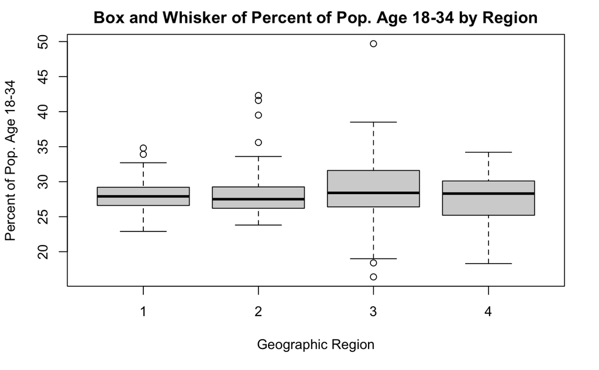

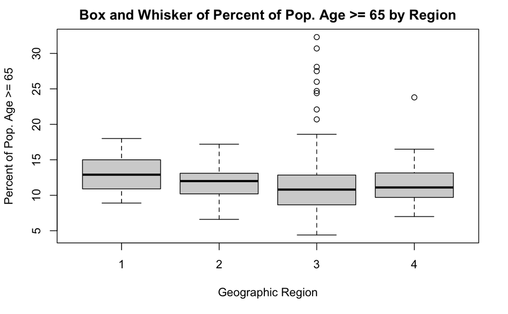

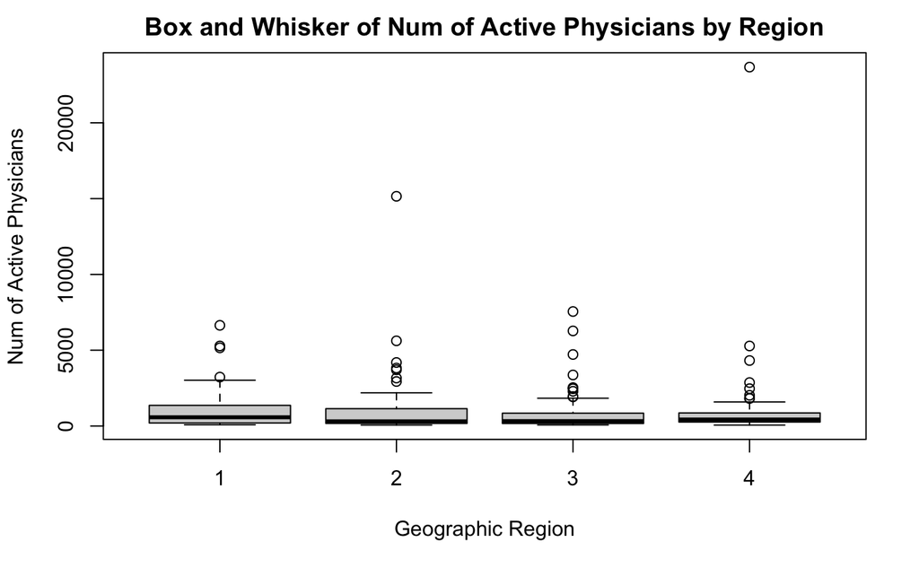

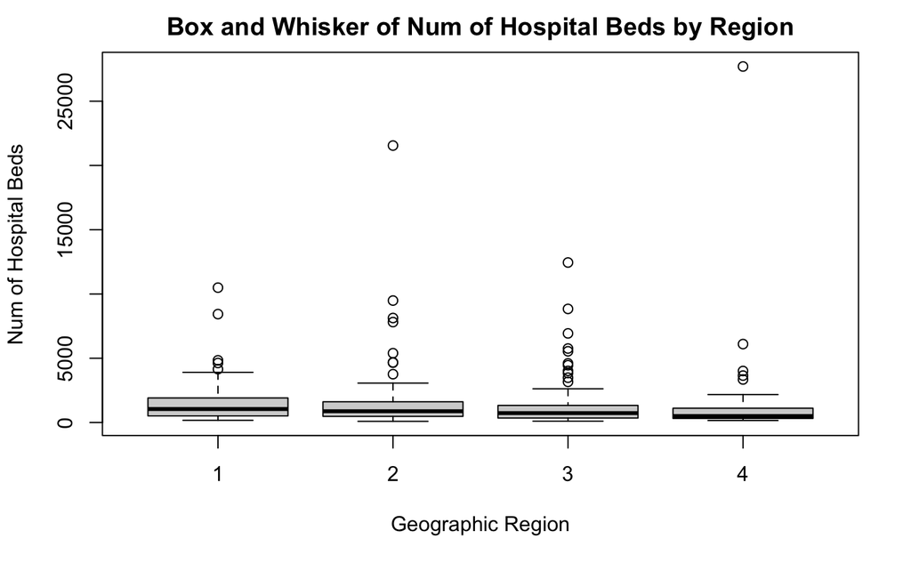

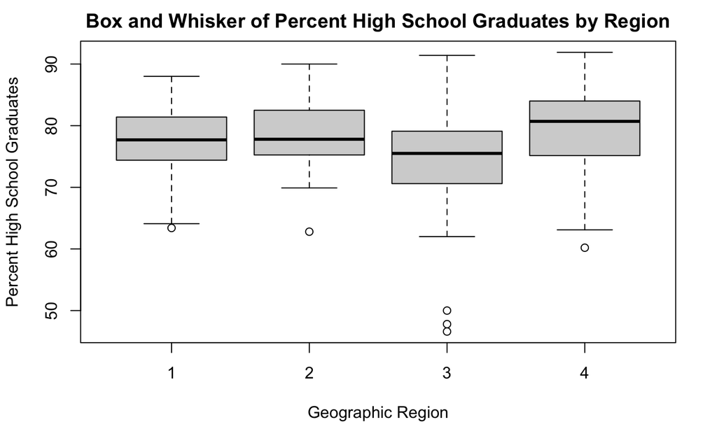

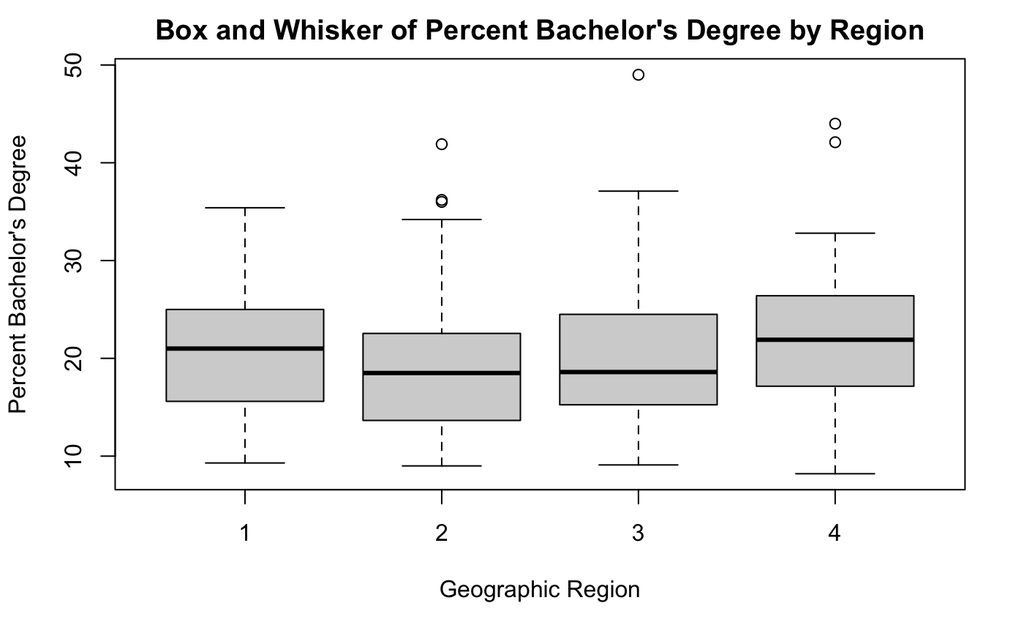

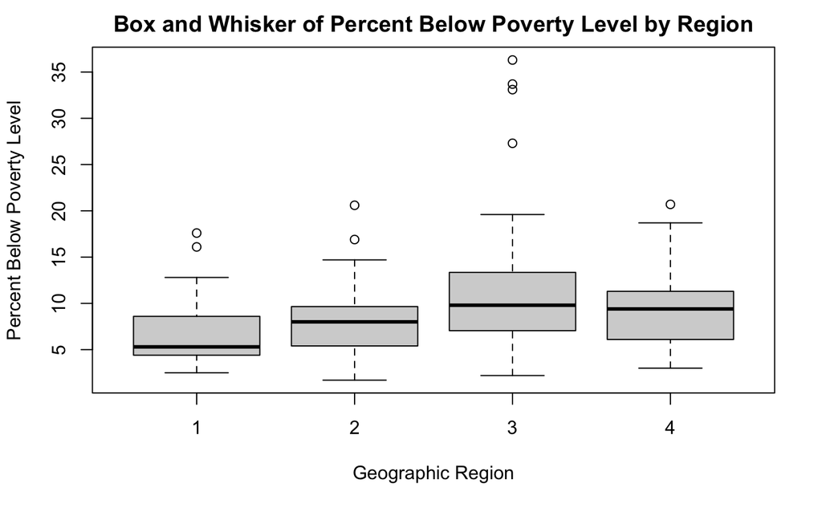

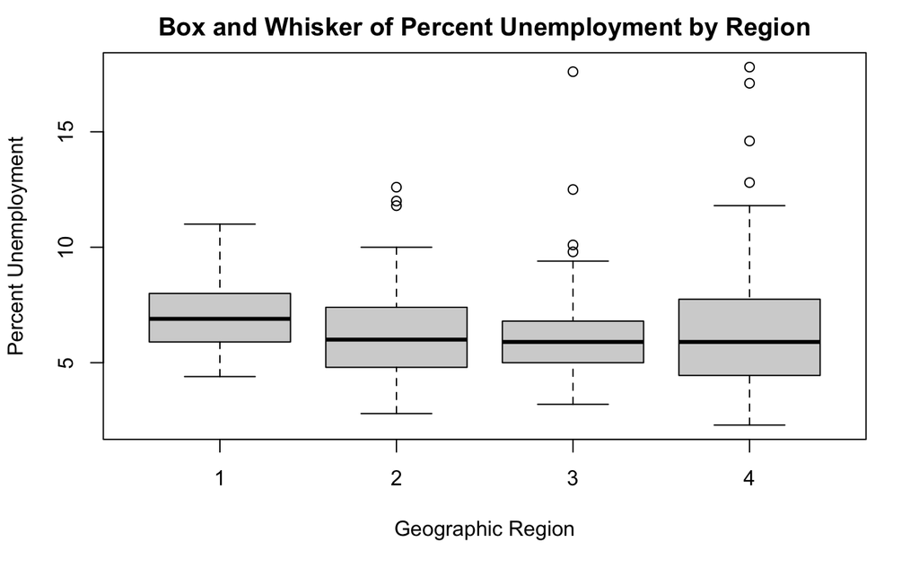

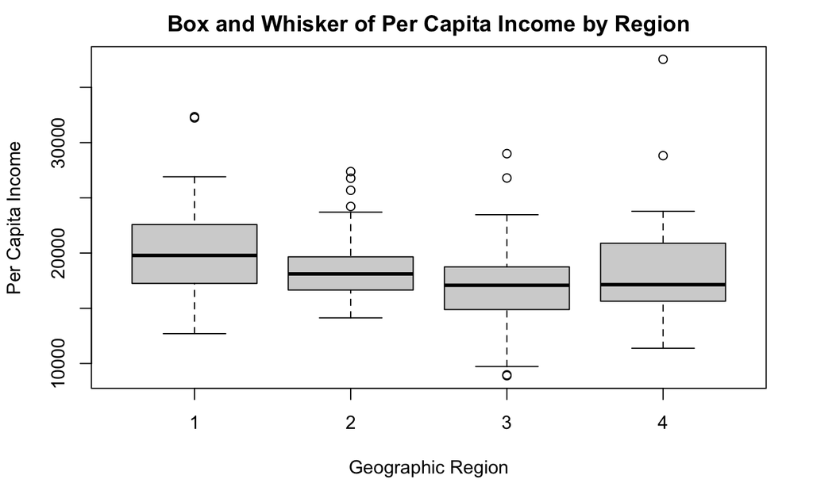

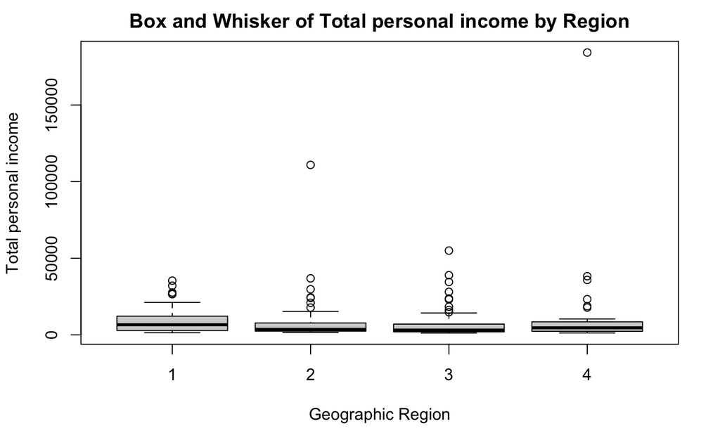

```r
# Select variables
selected_data <- subset(crime, select = -c(Id, `County Name`, State,`Land Area`, `Total Pop.`, `Total Serious Crimes`))
d <- dim(selected_data)[2]
#par(mfrow=c(ceiling(sqrt(d)), ceiling(sqrt(d))))
#crime$`Geographic Region` <- as.factor(crime$`Geographic Region`)

for(i in 1:(d-1)){
  title_string <- paste("Box and Whisker of ", colnames(selected_data)[i], " by Region", sep = "")
  #formula_string <- paste("Geographic Region ~ ", colnames(selected_data)[i], sep = "")
  #plot_formula <- as.formula(formula_string)

  boxplot(selected_data[, i] ~ `Geographic Region`, data = selected_data, main=title_string,
   xlab="Geographic Region", ylab=colnames(selected_data)[i])
}
```